# Assignment 7: Data wrangling and plotting

Alex Takoudes

2023-01-24

```r
#SETUP
library(ggplot2)
library(ggthemes)
library(patchwork)
library(dplyr)
##
## Attaching package: 'dplyr'
## The following objects are masked from 'package:stats':
##
##     filter, lag
## The following objects are masked from 'package:base':
##
##     intersect, setdiff, setequal, union
library(viridis)
## Loading required package: viridisLite
```

##### 1. Using the built-in starwars data set in the dplyr package, create a new tibble with the following modifications:

- It only includes the species that have more than 1 individual represented in the data set. (hint: first use dplyr to summarize the number of individuals per species in the data frame; then create a vector/tibble of those names; subset the species that are included in that vector)
- It only includes the columns that are not of type list (hint: use glimpse to check)

```r
data(starwars)

stw_grouped <- starwars %>%
  group_by(species) %>%      #group all the species
  summarize(number= n()) %>% #find how many things are in each
  filter(number>1)           #pick only the species with more than one individual



big_species <- starwars %>%  #we're filtering the big starwars dataset, but lets save a new one
  filter(species %in% stw_grouped$species) %>% #only pick the species >1
  select(-(films:starships)) #get rid of the last three columns which are lists

#n <- names(select_if(big_species, is.list)[c(1:3))
#n

glimpse(big_species)
```

```
## Rows: 58
## Columns: 11
## $ name       <chr> "Luke Skywalker", "C-3PO", "R2-D2", "Darth Vader", "Leia Or…
## $ height     <int> 172, 167, 96, 202, 150, 178, 165, 97, 183, 182, 188, 180, 2…
## $ mass       <dbl> 77.0, 75.0, 32.0, 136.0, 49.0, 120.0, 75.0, 32.0, 84.0, 77.…
## $ hair_color <chr> "blond", NA, NA, "none", "brown", "brown, grey", "brown", N…
## $ skin_color <chr> "fair", "gold", "white, blue", "white", "light", "light", "…
## $ eye_color  <chr> "blue", "yellow", "red", "yellow", "brown", "blue", "blue",…
## $ birth_year <dbl> 19.0, 112.0, 33.0, 41.9, 19.0, 52.0, 47.0, NA, 24.0, 57.0, …
## $ sex        <chr> "male", "none", "none", "male", "female", "male", "female",…
## $ gender     <chr> "masculine", "masculine", "masculine", "masculine", "femini…
## $ homeworld  <chr> "Tatooine", "Tatooine", "Naboo", "Tatooine", "Alderaan", "T…
## $ species    <chr> "Human", "Droid", "Droid", "Human", "Human", "Human", "Huma…
```

##### 2. Clean your data set: only include observations/rows that do not have an NA in the height column. Then, use dplyr to print a summary table showing the mean, median, and standard deviation of height for each species.

```r
big_clean_species <- big_species[complete.cases(big_species$height),]
anyNA(big_clean_species$height)
```

```
## [1] FALSE
```

```r
big_clean_species %>%
  group_by(species) %>%
  summarize(mean=mean(height), median=median(height), stdev=sd(height)) %>%
  print()
```

```
## # A tibble: 9 × 4
##   species   mean median stdev
##   <chr>    <dbl>  <dbl> <dbl>
## 1 Droid     131.     97 49.1
## 2 Gungan    209.    206 14.2
## 3 Human     177.    180 12.5
## 4 Kaminoan  221     221 11.3
## 5 Mirialan  168     168  2.83
## 6 Twi'lek   179     179  1.41
## 7 Wookiee   231     231  4.24
## 8 Zabrak    173     173  2.83
## 9 <NA>      181.    183  2.89
```

##### 3. Create a box plot figure that shows the variation in heights among Star Wars species. Do the values in your summary table line up with the plot? Code so that each box plot (Species) is be filled with a different color. Change your axes labels so that species is capitalized and height is capitalized and shows units (cm). Use the theme_minimal option. Then look into the annotate or geom_text functions and add the text “p=1.2E-0.5” to the top right corner.

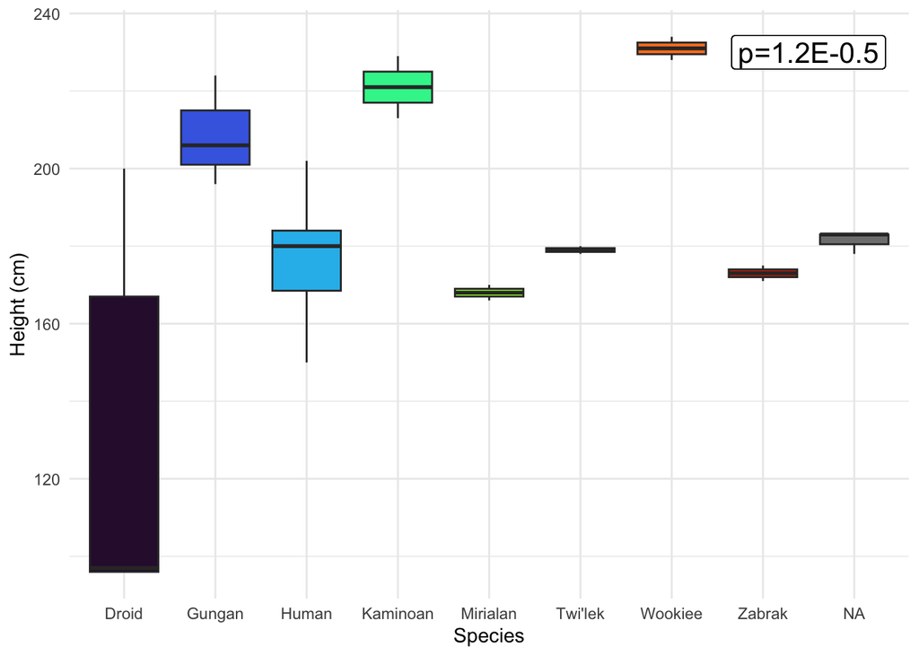

```r
cols <- viridis(count(stw_grouped), option="turbo")

annotation <- data.frame(
   x = 8,
   y = 200,
   label = "label"
)


plot_h <- ggplot(big_clean_species, aes(x=species, y=height, fill=species)) +
  geom_boxplot(show.legend=F) +
  geom_label(label="p=1.2E-0.5", x=8.5, y=230, size=5.5, fill="white", show.legend=F) +
  scale_fill_manual(values=cols) +
  xlab("Species") +
  ylab("Height (cm)") +
  theme_minimal()

plot_h
```

#### For an extra (optional) challenge: overlay the data points onto the box plots (hint: look into geom_jitter or geom_point). See if you can change the color of the points, depending on the gender or sex variables.

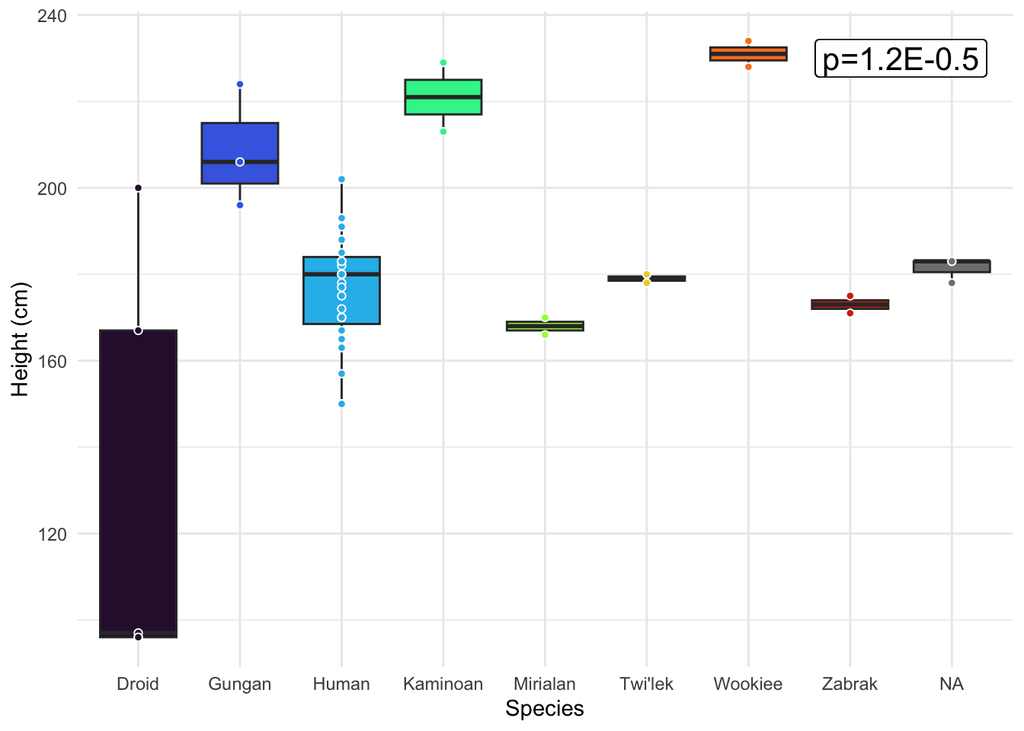

```r
plot_h <- plot_h +
    geom_point(shape=21, color="white", show.legend=F) #add points to the graph. after boxplot so no overlap

plot_h
```

##### 4. Using the same or a different built-in data set, create at least one additional (and different kind of) plot. Experiment with different arguments, features, and colors.

```r
data(mpg)

hwy_mpg <- mpg %>%
  group_by(class) %>%           #group by vehicle type
  summarize(mpg=mean(hwy)) %>%  #calculate average mpg for vehicle type
  mutate(Roads="Highway")            #add "type" column to help with bar chart

cty_mpg <- mpg %>%              #repeat for city mpg
  group_by(class) %>%
  summarize(mpg=mean(cty)) %>%
  mutate(Roads="City")

combined_mpg <- rbind(hwy_mpg, cty_mpg) %>%  #use rbind (combine by rows). Adds two 3x7 tibbles into one 3x14
  arrange(by=class) %>% #for neatness, put the same vehicle types next to each other
  print()
```

```
## # A tibble: 14 × 3
##    class        mpg Roads
##    <chr>      <dbl> <chr>
##  1 2seater     24.8 Highway
##  2 2seater     15.4 City
##  3 compact     28.3 Highway
##  4 compact     20.1 City
##  5 midsize     27.3 Highway
##  6 midsize     18.8 City
##  7 minivan     22.4 Highway
##  8 minivan     15.8 City
##  9 pickup      16.9 Highway
## 10 pickup      13   City
## 11 subcompact  28.1 Highway
## 12 subcompact  20.4 City
## 13 suv         18.1 Highway
## 14 suv         13.5 City
```

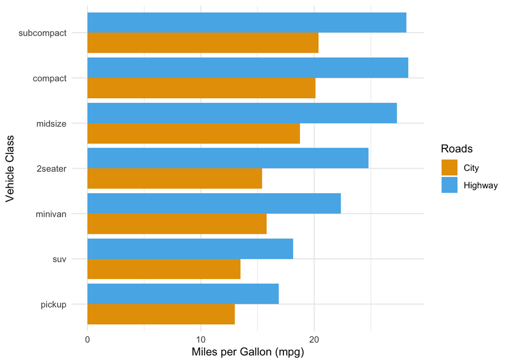

```r
colors <- viridis(2, option="turbo")

mpg_plot <- ggplot(combined_mpg, aes(x=reorder(class, mpg), y=mpg, fill=Roads, levels=mpg, decreasing=T)) +
  #x=reorder reorders x axis by the mpg values
  geom_bar(position="dodge", stat="identity") + #position= "dodge" makes the bars side by side
  coord_flip() +
  theme_minimal() +
  ylab("Miles per Gallon (mpg)") +
  xlab("Vehicle Class") +
  scale_fill_manual(values=(c("#E69F00", "#56B4E9")))

mpg_plot
```

##### 5. Finally, create a multi-panel figure with the graphs you created.

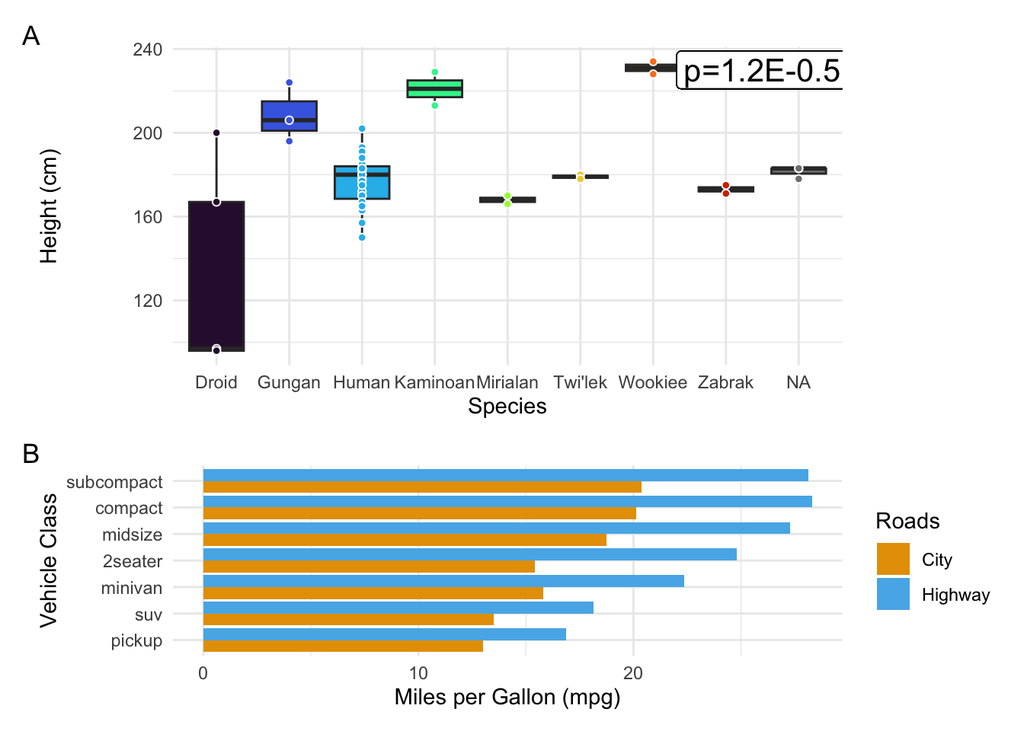

```r
multiplot <- (plot_h/mpg_plot) +
  plot_layout(heights=c(5,3)) +
  plot_annotation(tag_levels = 'A')

multiplot
```